# Speed Datings

14 de outubro de 2016

# OS DADOS

Para essa análise, serão utilizados os seguintes atributos:

- samerace -> Indica se as duas pessoas são da mesma raça
- attr -> O quão a pessoa achou a outra atraente
- sinc -> O quão a pessoa achou a outra sincera
- intel -> O quão a pessoa achou a outra inteligente
- fun -> O quão a pessoa achou a outra divertida
- amb -> O quão a pessoa achou a outra ambiciosa
- shar -> O quão a pessoa achou que os dois compartilham dos mesmos hobbies e interesses
- dif_age -> A diferença de idade entre as duas pessoas

```r
ler_dados <- function(arquivo){
  require("dplyr", warn.conflicts = FALSE)

  dados = read.csv(arquivo, stringsAsFactors = FALSE, encoding='UTF-8')
  return(dados)
}

speed_datings = ler_dados("speed-dating2.csv")
speed_datings = speed_datings %>% mutate(dif_age = abs(age_o - age))
speed_datings = speed_datings %>% mutate(match = ifelse(dec == "yes", 1, 0))
speed_datings = speed_datings %>% select(6,30,31,32,33,34,35,45,46)
speed_datings$match <- as.factor(speed_datings$match)
speed_datings$samerace <- as.factor(speed_datings$samerace)
speed_datings <- na.omit(speed_datings)
```

# 1. Que fatores nos dados têm efeito significativo na chance do casal ter um match? E como é esse efeito (positivo/negativo)?

Abaixo, foi gerada uma regressão logística, que originou os seguintes coeficientes para cada atributo (com seus respectivos intervalos de confiança).

Os seguintes fatores têm efeito significativo

:

- attr (Efeito positivo)
- sinc (Efeito negativo)
- fun (Efeito postivo)
- amb (Efeito negativo)
- shar (Efeito positivo)

Os outros fatores (samerace, intel e dif_age) contém o 0 em seus intervalos de confiança, indicando que não são considerados significativos. Ou seja, para esse modelo, o fato de os dois terem a mesma raça ou não, a inteligência da outra pessoa e a diferença de idade entre elas não influencia no match.

```r
model <- glm(match ~ .,
          data = speed_datings,
          family = "binomial")

tidy(model, conf.int = TRUE)
```

```
##          term     estimate  std.error   statistic      p.value    conf.low
## 1 (Intercept) -4.991989263 0.25120127 -19.8724680 7.045242e-88 -5.49083225
## 2   samerace1 -0.079222201 0.07873117  -1.0062368 3.143017e-01 -0.23375509
## 3        attr  0.565547436 0.02890524  19.5655648 3.040163e-85  0.50951623
## 4        sinc -0.126425750 0.03179919  -3.9757536 7.015672e-05 -0.18887918
## 5       intel  0.005720243 0.03920477   0.1459068 8.839950e-01 -0.07123219
## 6         fun  0.250856988 0.03111686   8.0617704 7.519737e-16  0.19012155
## 7         amb -0.190860227 0.03083106  -6.1905172 5.996714e-10 -0.25158550
## 8        shar  0.321741456 0.02446307  13.1521298 1.654476e-39  0.27413257
## 9     dif_age -0.018355235 0.01439375  -1.2752228 2.022304e-01 -0.04661703
##      conf.high
## 1 -4.505948628
## 2  0.074924193
## 3  0.622851952
## 4 -0.064189828
## 5  0.082490115
## 6  0.312132399
## 7 -0.130697232
## 8  0.370054893
## 9  0.009825947
```

```r
confint(model)
```

```
##                   2.5 %       97.5 %
## (Intercept) -5.49083225 -4.505948628
## samerace1   -0.23375509  0.074924193
## attr         0.50951623  0.622851952
## sinc        -0.18887918 -0.064189828
## intel       -0.07123219  0.082490115
## fun          0.19012155  0.312132399
## amb         -0.25158550 -0.130697232
## shar         0.27413257  0.370054893
## dif_age     -0.04661703  0.009825947
```

Para dar um maior sentido aos coeficientes encontrados, podemos exponenciá-los, obtendo agora:

```r
tidy(model, conf.int = TRUE, exponentiate = TRUE)
```

```
##          term   estimate  std.error   statistic      p.value   conf.low
## 1 (Intercept) 0.00679214 0.25120127 -19.8724680 7.045242e-88 0.00412441
## 2   samerace1 0.92383463 0.07873117  -1.0062368 3.143017e-01 0.79155565
## 3        attr 1.76041123 0.02890524  19.5655648 3.040163e-85 1.66448578
## 4        sinc 0.88123958 0.03179919  -3.9757536 7.015672e-05 0.82788652
## 5       intel 1.00573663 0.03920477   0.1459068 8.839950e-01 0.93124564
## 6         fun 1.28512628 0.03111686   8.0617704 7.519737e-16 1.20939660
## 7         amb 0.82624807 0.03083106  -6.1905172 5.996714e-10 0.77756698
## 8        shar 1.37952806 0.02446307  13.1521298 1.654476e-39 1.31538917
## 9     dif_age 0.98181220 0.01439375  -1.2752228 2.022304e-01 0.95445286
##    conf.high
## 1 0.01104311
## 2 1.07780244
## 3 1.86423718
## 4 0.93782696
## 5 1.08598794
## 6 1.36633558
## 7 0.87748341
## 8 1.44781409
## 9 1.00987438
```

# 2. Que fatores nos dados têm mais efeito na chance de um casal ter match?

O que apresenta um maior coeficiente estimado (0.56) é o attr, ou seja, a aparência da outra pessoa. Além dele, temos o shar (0.32), indicando o quão a pessoa achou que os dois compartilham dos mesmos hobbies e interesses, e o fun (0.25), que indica o quão a pessoa achou a outra divertida.

O pseudo R² encontrado foi de 0.30. O valor desse pseudo R², em geral, é menor que o valor do R² normal que calcula-se na regressão linear. Um valor entre 0.20 e 0.40 já indica uma boa explicação da variabilidade dos dados.

```r
pR2(model)
```

```
##           llh       llhNull            G2      McFadden          r2ML
## -2032.3833151 -2760.0756474  1455.3846645     0.2636494     0.3020589
##          r2CU
##     0.4057933
```

# O modelo gerado prevê bem a variável match?

Para analisar isso, foi feita uma comparação entre o que o modelo estimaria tendo os dados em mãos e o que de fato temos nos dados.

Na maioria dos casos ele prevê que houve match quando realmente houve, assim como na maioria na vezes que prevê que não aconteceu match, realmente não aconteceu.

```r
predictions <- predict(model, type = "response") > .5
true_match <- speed_datings$match == 1

table(predictions, true_match)
```

```
##            true_match
## predictions FALSE TRUE
##       FALSE  1864  566
##       TRUE    461 1156
```

```r
require(vcd)
```

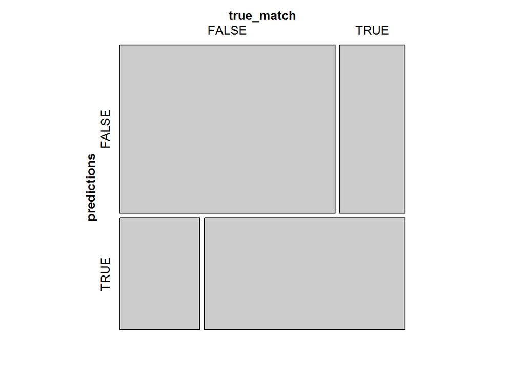

```r
mosaic(table(predictions, true_match))
```

Sendo mais prático, abaixo temos a precisão do modelo, que mostra que ele acertou a previsão em aproximadamente 75% das observações.

```r
erro <- sum((predictions != true_match)) / NROW(predictions)
accuraccy = 1 - erro
accuraccy
```

```
## [1] 0.7462318
```